# Segmented regression of age-standardised mortality rates - Scotland all-ages Q1 1990 to Q2 2018

# Introduction

To undertake segmented regression (one and two-break models) for Scotland, all-ages, age-standardised mortality rates(ASMR). Employs full data range available (Q1 1990-Q2 2018). Quarterly annual ASMR employ the 2013 European Standard Popualtion, and were provided by National Records for Scotland.

Contents:

- Load packages, load data, tidy data labels, and convert dates to identifiable quarters
- Plot observed data
- Generate, view and plot linear model
- Run Davies test to identify and test signifcance of single break point
- Generate and view one breakpoint segmented model
- Extract breakpoints and confidence intervals
- Plot one breakpoint model
- Generate two break segmented model
- Use AIC and BIC to compare fit of one and two break models
- Plot two breakpoint model

## Load packages

```r
#install.packages("pacman")
pacman::p_load(
  tidyverse,
  segmented,
  plotly,
  dplyr,
  readr,
  ggplot2,
  broom,
  tidyr
               )
```

## Load data and assign to object “data”

```r
data <- read.csv("Data/QuarterlyASMR1990_2018.csv")
data
```

| period | sex | allageesprate | allagestderr | allagelcli | allageucli | under75esprate | under75stderr | under75lcli | under75ucli | totdeaths |
| --- | --- | --- | --- | --- | --- | --- | --- | --- | --- | --- |
| 19901 | F | 1500.4002 | 7.788046 | 1485.1356 | 1515.6648 | 589.2652 | 4.994766 | 579.4755 | 599.0550 | 34163 |
| 19901 | M | 2287.7414 | 13.950236 | 2260.3990 | 2315.0839 | 1010.2307 | 7.222368 | 996.0749 | 1024.3866 | 31360 |
| 19901 | P | 1796.2713 | 6.854256 | 1782.8370 | 1809.7056 | 777.9763 | 4.242511 | 769.6609 | 786.2916 | 65523 |
| 19902 | F | 1499.6691 | 7.774313 | 1484.4314 | 1514.9067 | 590.4938 | 4.998890 | 580.6960 | 600.2917 | 34216 |
| 19902 | M | 2271.7785 | 13.869048 | 2244.5951 | 2298.9618 | 1002.3490 | 7.183408 | 988.2696 | 1016.4285 | 31247 |
| 19902 | P | 1790.5826 | 6.830757 | 1777.1943 | 1803.9709 | 775.1230 | 4.230873 | 766.8305 | 783.4155 | 65463 |
| 19903 | F | 1485.5072 | 7.730787 | 1470.3549 | 1500.6596 | 588.0220 | 4.985508 | 578.2504 | 597.7936 | 33997 |
| 19903 | M | 2252.7301 | 13.786253 | 2225.7090 | 2279.7512 | 993.3030 | 7.136414 | 979.3157 | 1007.2904 | 31069 |
| 19903 | P | 1774.0388 | 6.788831 | 1760.7327 | 1787.3450 | 770.2041 | 4.212956 | 761.9467 | 778.4615 | 65066 |
| 19904 | F | 1386.2319 | 7.495202 | 1371.5413 | 1400.9225 | 563.1330 | 4.878688 | 553.5707 | 572.6952 | 31910 |

[output cut: 332 more lines]

# Tidy periods into quarters, select all age rate, filter to M&F only

```r
tidied_allagerates_2018 <-
  data %>%
  separate(period, into = c("year","quarter"), sep = 4) %>%
  mutate(
   year = as.double(year),
   quarter = as.double(quarter)
  ) %>%
  mutate(
    time = year + (quarter / 4) - 0.125
  ) %>%
  select(time, sex, allageesprate) %>%
  filter(sex!="P")

tidied_allagerates_2018
```

| time | sex | allageesprate |
| --- | --- | --- |
| 1990.125 | F | 1500.4002 |
| 1990.125 | M | 2287.7414 |
| 1990.375 | F | 1499.6691 |
| 1990.375 | M | 2271.7785 |
| 1990.625 | F | 1485.5072 |
| 1990.625 | M | 2252.7301 |
| 1990.875 | F | 1386.2319 |
| 1990.875 | M | 2114.4333 |
| 1991.125 | F | 1370.9937 |
| 1991.125 | M | 2090.4911 |

[output cut: 218 more lines]

# plot mortality rates by time

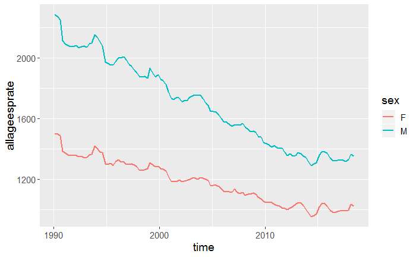

```r
plot<-ggplot(tidied_allagerates_2018,aes(x=time,y=allageesprate, color=sex))+geom_line(size=1.0001, show.legend = TRUE)+theme(text=element_text(size=14))
plot
```

## Generate linear model for both sexes

```r
tidied_allagerates_2018 %>%
  rename(rate = allageesprate) %>%
  filter(sex == "M") -> allagemale
  lm(rate ~ time, data = allagemale) -> lmod_male_2018
tidied_allagerates_2018 %>%
  rename(rate = allageesprate) %>%
  filter(sex == "F") -> allagefemale
  lm(rate ~ time, data = allagefemale) -> lmod_female_2018
```

## View linear model

```r
summary (lmod_male_2018)
```

```
Call:
lm(formula = rate ~ time, data = allagemale)

Residuals:
   Min     1Q Median     3Q    Max
-68.73 -38.87 -16.80  36.84 142.55

Coefficients:
             Estimate Std. Error t value Pr(>|t|)
(Intercept) 69951.244   1164.509   60.07   <2e-16 ***
time          -34.056      0.581  -58.62   <2e-16 ***
---
Signif. codes:  0 ‘***’ 0.001 ‘**’ 0.01 ‘*’ 0.05 ‘.’ 0.1 ‘ ’ 1

Residual standard error: 51.04 on 112 degrees of freedom
Multiple R-squared:  0.9684,    Adjusted R-squared:  0.9681
F-statistic:  3436 on 1 and 112 DF,  p-value: < 2.2e-16
```

```r
summary (lmod_female_2018)
```

```
Call:
lm(formula = rate ~ time, data = allagefemale)

Residuals:
    Min      1Q  Median      3Q     Max
-56.519 -24.836  -3.137  17.272  89.669

Coefficients:
              Estimate Std. Error t value Pr(>|t|)
(Intercept) 34630.7949   734.8493   47.13   <2e-16 ***
time          -16.6907     0.3666  -45.52   <2e-16 ***
---
Signif. codes:  0 ‘***’ 0.001 ‘**’ 0.01 ‘*’ 0.05 ‘.’ 0.1 ‘ ’ 1

Residual standard error: 32.21 on 112 degrees of freedom
Multiple R-squared:  0.9487,    Adjusted R-squared:  0.9483
F-statistic:  2072 on 1 and 112 DF,  p-value: < 2.2e-16
```

## Get trend line of linear model fit to whole timeseries

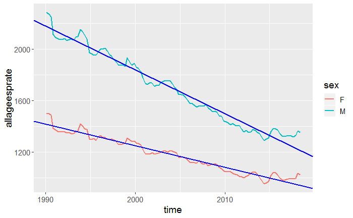

```r
my.coeftrendlinemale_2018 <- coef(lmod_male_2018)
my.coeftrendlinefemale_2018 <- coef(lmod_female_2018)
addtrendline <- plot + geom_abline(intercept = my.coeftrendlinemale_2018[1], col="Blue", size=1.0001,
                                       slope = my.coeftrendlinemale_2018[2],
                                       aes(colour = "Overall"))+
  geom_abline(intercept = my.coeftrendlinefemale_2018[1], col="Blue", size=1.0001,
                                       slope = my.coeftrendlinefemale_2018[2],
                                       aes(colour = "Overall"))
addtrendline
```

# Segmented regression

## Davies test - this is limited in a 2-break point analysis as currently the Davies test will only look for 1 breakpoint

```r
davies_allmale_2018 = davies.test(lmod_male_2018, ~time, k=107)
davies_allfemale_2018 = davies.test(lmod_female_2018, ~time, k=107)
davies_allmale_2018
```

```
    Davies' test for a change in the slope

data:  formula = rate ~ time ,   method = lm
model = gaussian , link = identity
segmented variable = time
'best' at = 2013.4, n.points = 105, p-value = 4.703e-16
alternative hypothesis: two.sided
```

```r
davies_allfemale_2018
```

```
    Davies' test for a change in the slope

data:  formula = rate ~ time ,   method = lm
model = gaussian , link = identity
segmented variable = time
'best' at = 2014.5, n.points = 105, p-value = 2.593e-08
alternative hypothesis: two.sided
```

## Segmented regression function - one break point

```r
 my.seg_male_2018<-segmented(  lmod_male_2018, seg_rate.Z = ~time, psi = NA, control = seg.control(K=1))
 my.seg_female_2018<-segmented(  lmod_female_2018, seg_rate.Z = ~time, psi = NA, control = seg.control(K=1))

summary(my.seg_male_2018)
```

```
    ***Regression Model with Segmented Relationship(s)***

Call:
segmented.lm(obj = lmod_male_2018, psi = NA, control = seg.control(K = 1),
    seg_rate.Z = ~time)

Estimated Break-Point(s):
     Est.   St.Err
2013.495    0.464

Meaningful coefficients of the linear terms:
             Estimate Std. Error t value Pr(>|t|)
(Intercept) 76335.515   1118.969  68.220   <2e-16 ***
time          -37.250      0.559 -66.638   <2e-16 ***
U1.time        39.097      5.730   6.823       NA
---
Signif. codes:  0 ‘***’ 0.001 ‘**’ 0.01 ‘*’ 0.05 ‘.’ 0.1 ‘ ’ 1

Residual standard error: 36.76 on 110 degrees of freedom
Multiple R-Squared: 0.9839,  Adjusted R-squared: 0.9835

Convergence attained in 2 iterations with relative change 0
```

```r
summary(my.seg_female_2018)
```

```
    ***Regression Model with Segmented Relationship(s)***

Call:
segmented.lm(obj = lmod_female_2018, psi = NA, control = seg.control(K = 1),
    seg_rate.Z = ~time)

Estimated Break-Point(s):
     Est.   St.Err
2014.366    0.579

Meaningful coefficients of the linear terms:
              Estimate Std. Error t value Pr(>|t|)
(Intercept) 37366.2242   793.9947  47.061   <2e-16 ***
time          -18.0591     0.3966 -45.538   <2e-16 ***
U1.time        24.0199     5.4287   4.425       NA
---
Signif. codes:  0 ‘***’ 0.001 ‘**’ 0.01 ‘*’ 0.05 ‘.’ 0.1 ‘ ’ 1

Residual standard error: 27.34 on 110 degrees of freedom
Multiple R-Squared: 0.9637,  Adjusted R-squared: 0.9627

Convergence attained in 3 iterations with relative change 0
```

## Extract breakpoint and CI of one break model

```r
breakpointmale_2018 <- my.seg_male_2018$psi[, 2]
breakpointfemale_2018 <- my.seg_female_2018$psi[, 2]
breakpoint_SEmale_2018 <- my.seg_male_2018$psi[, 3]
breakpoint_SEfemale_2018 <- my.seg_female_2018$psi[, 3]
breakpoint_low_CImale_2018 <- breakpointmale_2018 - (breakpoint_SEmale_2018*1.96)
breakpoint_up_CImale_2018 <- breakpointmale_2018 + (breakpoint_SEmale_2018*1.96)
breakpoint_low_CIfemale_2018 <- breakpointfemale_2018 - (breakpoint_SEfemale_2018*1.96)
breakpoint_up_CIfemale_2018 <- breakpointfemale_2018 + (breakpoint_SEfemale_2018*1.96)
breakpointmale_2018
```

```
[1] 2013.495
```

```r
breakpoint_low_CImale_2018
```

```
[1] 2012.585
```

```r
breakpoint_up_CImale_2018
```

```
[1] 2014.404
```

```r
breakpointfemale_2018
```

```
[1] 2014.366
```

```r
breakpoint_low_CIfemale_2018
```

```
[1] 2013.231
```

```r
breakpoint_up_CIfemale_2018
```

```
[1] 2015.501
```

## Generate and plot predicted values from one break model

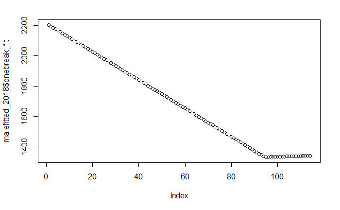

```r
tidied_allagerates_2018 %>%
  filter(sex == "M") %>%
  mutate(
    onebreak_fit = fitted(
      my.seg_male_2018

      )
    ) -> malefitted_2018
tidied_allagerates_2018 %>%
  filter(sex == "F") %>%
  mutate(
    onebreak_fit = fitted(
      my.seg_female_2018
      )
    ) -> femalefitted_2018
plot(malefitted_2018$onebreak_fit)
```

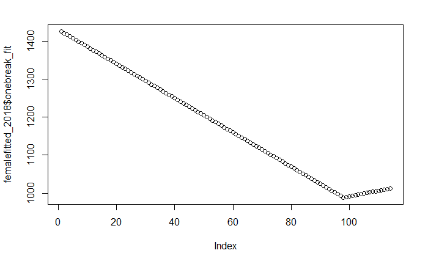

```r
plot(femalefitted_2018$onebreak_fit)
```

## Combine male and female observed and predicted values in single data frame

```r
femalefitted_2018 %>%
  select(
    time, sex, observed = allageesprate,
    predicted = onebreak_fit
  ) %>%
  bind_rows(
    malefitted_2018 %>%
      select(
        time, sex, observed = allageesprate,
        predicted = onebreak_fit
      )
  ) -> obs_fit_both_2018
age <- "all"
obs_fit_both_2018$agegroup = age
obs_fit_both_2018
```

| time | sex | observed | predicted | agegroup |
| --- | --- | --- | --- | --- |
| 1990.125 | F | 1500.4002 | 1426.3064 | all |
| 1990.375 | F | 1499.6691 | 1421.7917 | all |
| 1990.625 | F | 1485.5072 | 1417.2769 | all |
| 1990.875 | F | 1386.2319 | 1412.7621 | all |
| 1991.125 | F | 1370.9937 | 1408.2473 | all |
| 1991.375 | F | 1361.9806 | 1403.7325 | all |
| 1991.625 | F | 1356.4288 | 1399.2178 | all |
| 1991.875 | F | 1359.8080 | 1394.7030 | all |
| 1992.125 | F | 1358.5900 | 1390.1882 | all |
| 1992.375 | F | 1349.7919 | 1385.6734 | all |

[output cut: 218 more lines]

# Plot observed values with linear and segmented models

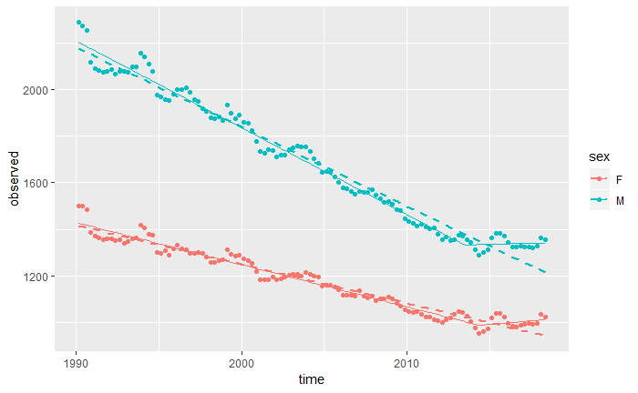

```r
obs_fit_both_2018 %>%
  ggplot(
    aes (x=time, color=sex)
  ) +
  geom_point(
    aes (y=observed)) +
  geom_line (
    aes (y=predicted)) +
  stat_smooth(method="lm",se=F,linetype="dashed",
    aes (y=observed)
  )
```

## Getsegmented regression coefficients to inform plot of continuation of pre-breakpoint trend

```r
coef(my.seg_male_2018)
```

```
(Intercept)        time     U1.time   psi1.time
76335.51522   -37.25018    39.09740     0.00000
```

```r
coef(my.seg_female_2018)
```

```
(Intercept)        time     U1.time   psi1.time
37366.22423   -18.05913    24.01989     0.00000
```

## Annotated plot of observed data, segmented model, and continutation of pre-breakpoint trend

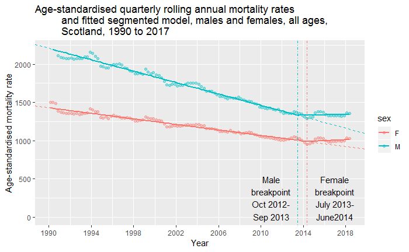

```r
 # Get coeffiencents male
  b0_aspec_m_2018 <- coef(my.seg_male_2018)[[1]]
  b1_aspec_m_2018 <- coef(my.seg_male_2018)[[2]]
  c1_aspec_m_2018 <- coef(my.seg_male_2018)[[2]] + coef(my.seg_male_2018)[[3]]

  break1_aspec_m_2018 <- my.seg_male_2018$psi[[2]]

  # Get coefficients female
    b0_aspec_f_2018 <- coef(my.seg_female_2018)[[1]]
  b1_aspec_f_2018 <- coef(my.seg_female_2018)[[2]]
  c1_aspec_f_2018 <- coef(my.seg_female_2018)[[2]] + coef(my.seg_female_2018)[[3]]

  break1_aspec_f <- my.seg_female_2018$psi[[2]]

# plot
 p <- obs_fit_both_2018 %>%
  ggplot(
    aes (x=time, color=sex)
  ) +
  geom_point(
    aes (y=observed), alpha=0.4) +
  geom_line (
    aes (y=predicted), size=1) +
  geom_abline(intercept = b0_aspec_m_2018, slope = b1_aspec_m_2018, color="#00BFC4", linetype="dashed") +
    geom_abline(intercept = b0_aspec_f_2018, slope = b1_aspec_f_2018, color="#F8766D", linetype= "dashed") +
    ylim(0,2200)+
    labs(x="Year", y="Age-standardised mortality rate", title =
        "Age-standardised quarterly rolling annual mortality rates
         and fitted segmented model, males and females, all ages,
         Scotland, 1990 to 2017") +
    scale_x_continuous (breaks=c(1990, 1994, 1998, 2002, 2006, 2010, 2014, 2018))+
      geom_vline(xintercept = my.seg_male_2018[["psi"]][[2]], color = "#00BFC4", linetype="dotdash")+
    geom_vline(xintercept = my.seg_female_2018[["psi"]][[2]], color = "#F8766D", linetype="dotdash") +
   annotate(geom="text", x=2011, y=250, label="Male\nbreakpoint\nOct 2012-\n Sep 2013 ")+
   annotate(geom="text", x=2017, y=250, label="Female\nbreakpoint\nJuly 2013-\nJune2014")


 plot(p)

    ggsave (
    "Figures/Segmentedplot_Scotland_Allagesto2018.png", height=15, width=20, units="cm")
```

## Segmented regression with two breakpoints

```r
my.seg_male2_2018 <-segmented( lmod_male_2018, seg_rate.Z = ~timepoint, psi = NA, control = seg.control(K=2))
my.seg_female2_2018<- segmented(lmod_female_2018, seg_rate.Z = ~timepoint, psi = NA, control = seg.control(K=2))
summary(my.seg_male2_2018)
```

```
    ***Regression Model with Segmented Relationship(s)***

Call:
segmented.lm(obj = lmod_male_2018, psi = NA, control = seg.control(K = 2),
    seg_rate.Z = ~timepoint)

Estimated Break-Point(s):
               Est. St.Err
psi1.time 1990.855  0.328
psi2.time 2013.732  0.444

Meaningful coefficients of the linear terms:
              Estimate Std. Error t value Pr(>|t|)
(Intercept) 389746.628 195677.709   1.992   0.0489 *
time          -194.680     98.312  -1.980   0.0502 .
U1.time        158.078     98.313   1.608       NA
U2.time         39.641      5.849   6.777       NA
---
Signif. codes:  0 ‘***’ 0.001 ‘**’ 0.01 ‘*’ 0.05 ‘.’ 0.1 ‘ ’ 1

Residual standard error: 34.76 on 108 degrees of freedom
Multiple R-Squared: 0.9859,  Adjusted R-squared: 0.9852

Convergence attained in 6 iterations with relative change -4.479232e-16
```

```r
summary(my.seg_female2_2018)
```

```
    ***Regression Model with Segmented Relationship(s)***

Call:
segmented.lm(obj = lmod_female_2018, psi = NA, control = seg.control(K = 2),
    seg_rate.Z = ~timepoint)

Estimated Break-Point(s):
               Est. St.Err
psi1.time 1990.956  0.194
psi2.time 2014.362  0.574

Meaningful coefficients of the linear terms:
              Estimate Std. Error t value Pr(>|t|)
(Intercept) 285238.625  88235.900   3.233  0.00163 **
time          -142.562     44.329  -3.216  0.00172 **
U1.time        125.023     44.330   2.820       NA
U2.time         22.079      4.922   4.486       NA
---
Signif. codes:  0 ‘***’ 0.001 ‘**’ 0.01 ‘*’ 0.05 ‘.’ 0.1 ‘ ’ 1

Residual standard error: 24.78 on 108 degrees of freedom
Multiple R-Squared: 0.9707,  Adjusted R-squared: 0.9694

Convergence attained in 16 iterations with relative change -0.00264149
```

## AIC and BIC to compare one and two break models

```r
AIC(my.seg_male_2018, my.seg_male2_2018)
```

|  | df | AIC |
| --- | --- | --- |
| my.seg_male_2018 | 5 | 1151.276 |
| my.seg_male2_2018 | 7 | 1140.395 |

```r
AIC(my.seg_female_2018, my.seg_female2_2018)
```

|  | df | AIC |
| --- | --- | --- |
| my.seg_female_2018 | 5 | 1083.755 |
| my.seg_female2_2018 | 7 | 1063.246 |

```r
BIC(my.seg_male_2018, my.seg_male2_2018)
```

|  | df | BIC |
| --- | --- | --- |
| my.seg_male_2018 | 5 | 1164.957 |
| my.seg_male2_2018 | 7 | 1159.549 |

```r
BIC(my.seg_female_2018, my.seg_female2_2018)
```

|  | df | BIC |
| --- | --- | --- |
| my.seg_female_2018 | 5 | 1097.436 |
| my.seg_female2_2018 | 7 | 1082.400 |

## Construct two break chart - generate predicted values for 2 break model

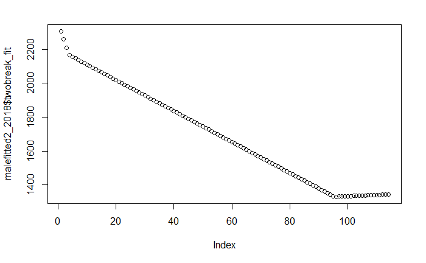

```r
tidied_allagerates_2018 %>%
  filter(sex == "M") %>%
  mutate(
    twobreak_fit = fitted(
      my.seg_male2_2018

      )
    ) -> malefitted2_2018
tidied_allagerates_2018 %>%
  filter(sex == "F") %>%
  mutate(
    twobreak_fit = fitted(
      my.seg_female2_2018
      )
    ) -> femalefitted2_2018
plot(malefitted2_2018$twobreak_fit)
```

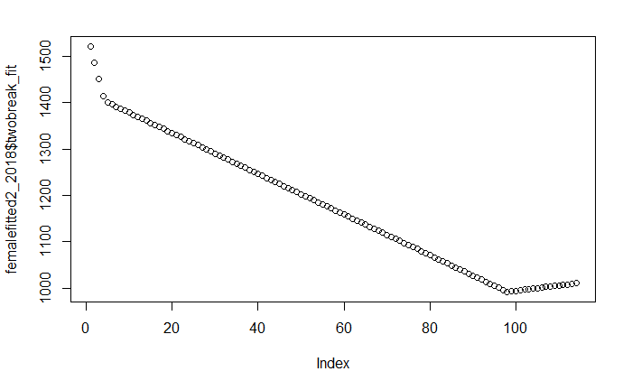

```r
plot(femalefitted2_2018$twobreak_fit)
```

## Combine male and female observed and predicted - 2 break

```r
femalefitted2_2018 %>%
  select(
    time, sex, observed = allageesprate,
    predicted = twobreak_fit
  ) %>%
  bind_rows(
    malefitted2_2018 %>%
      select(
        time, sex, observed = allageesprate,
        predicted = twobreak_fit
      )
  ) -> obs_fit_both_2018_2break
age <- "all"
obs_fit_both_2018_2break$agegroup = age
obs_fit_both_2018_2break
```

| time | sex | observed | predicted | agegroup |
| --- | --- | --- | --- | --- |
| 1990.125 | F | 1500.4002 | 1521.4309 | all |
| 1990.375 | F | 1499.6691 | 1485.7903 | all |
| 1990.625 | F | 1485.5072 | 1450.1497 | all |
| 1990.875 | F | 1386.2319 | 1414.5090 | all |
| 1991.125 | F | 1370.9937 | 1399.9941 | all |
| 1991.375 | F | 1361.9806 | 1395.6092 | all |
| 1991.625 | F | 1356.4288 | 1391.2243 | all |
| 1991.875 | F | 1359.8080 | 1386.8395 | all |
| 1992.125 | F | 1358.5900 | 1382.4546 | all |
| 1992.375 | F | 1349.7919 | 1378.0698 | all |

[output cut: 218 more lines]

# Extract breakpoint and CI for 2 break model

```r
breakpointmale_2018_2break <- my.seg_male2_2018$psi[, 2]
breakpointfemale_2018_2break <- my.seg_female2_2018$psi[, 2]
breakpoint_SEmale_2018_2break <- my.seg_male2_2018$psi[, 3]
breakpoint_SEfemale_2018_2break <- my.seg_female2_2018$psi[, 3]
breakpoint_low_CImale_2018_2break <- breakpointmale_2018_2break - (breakpoint_SEmale_2018_2break*1.96)
breakpoint_up_CImale_2018_2break <- breakpointmale_2018_2break + (breakpoint_SEmale_2018_2break*1.96)
breakpoint_low_CIfemale_2018_2break <- breakpointfemale_2018_2break - (breakpoint_SEfemale_2018_2break*1.96)
breakpoint_up_CIfemale_2018_2break <- breakpointfemale_2018_2break + (breakpoint_SEfemale_2018_2break*1.96)
breakpointmale_2018_2break
```

```
psi1.time psi2.time
 1990.855  2013.732
```

```r
breakpoint_low_CImale_2018_2break
```

```
psi1.time psi2.time
 1990.213  2012.861
```

```r
breakpoint_up_CImale_2018_2break
```

```
psi1.time psi2.time
 1991.497  2014.602
```

```r
breakpointfemale_2018_2break
```

```
psi1.time psi2.time
 1990.956  2014.362
```

```r
breakpoint_low_CIfemale_2018_2break
```

```
psi1.time psi2.time
 1990.576  2013.238
```

```r
breakpoint_up_CIfemale_2018_2break
```

```
psi1.time psi2.time
 1991.336  2015.487
```

## 2 break segmented plot

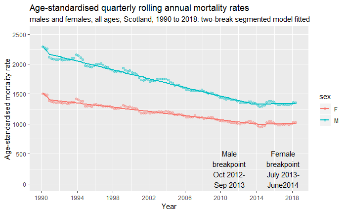

```r
segmentedplot_allage2break <- obs_fit_both_2018_2break %>%
  ggplot(
    aes (x=time, color=sex)
  ) +
  geom_point(
    aes (y=observed), alpha=0.4)+
  geom_line (
    aes (y=predicted), size=1) +
    ylim(0,2500)+
    labs(x="Year", y="Age-standardised mortality rate", title = "Age-standardised quarterly rolling annual mortality rates", subtitles="males and females, all ages, Scotland, 1990 to 2018: two-break segmented model fitted")+
 scale_x_continuous (breaks=c(1990, 1994, 1998, 2002, 2006, 2010, 2014, 2018))+ # Could also do breaks = seq(from = 1990, 2018, by = 4)
      geom_vline(xintercept = my.seg_male2_2018[["psi"]][[2]], color = "#00BFC4", linetype="dotdash")+
    geom_vline(xintercept = my.seg_female2_2018[["psi"]][[2]], color = "#F8766D", linetype="dotdash") +
   annotate(geom="text", x=2011, y=250, label="Male\nbreakpoint\nOct 2012-\n Sep 2013 ")+
   annotate(geom="text", x=2017, y=250, label="Female\nbreakpoint\nJuly 2013-\nJune2014")
segmentedplot_allage2break
    ggsave (
    "Figures/segmentedplotonly_Scotland_Allages_2break.png", height=15, width=20, units="cm")
```

# errorbar plot

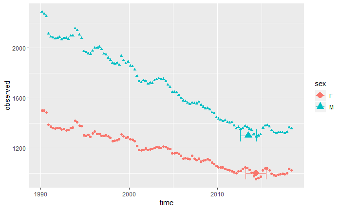

```r
obs_fit_both_2018 <- as_tibble(obs_fit_both_2018) # convert to 'nice' tibble format (better display)
temp_data <- tribble(
  ~ sex, ~time_min, ~time_max, ~y_pos,
  "M", breakpointmale_2018 - 2 * breakpoint_SEmale_2018, breakpointmale_2018 + 2 * breakpoint_SEmale_2018, 1300,
  "F", breakpointfemale_2018 - 2 * breakpoint_SEfemale_2018, breakpointfemale_2018 + 2 * breakpoint_SEfemale_2018, 1000
)
obs_fit_both_2018 %>%
   ggplot(
     aes(x = time, y = observed, color = sex, shape = sex)
     ) +
  geom_point(aes(y=observed)) +
  geom_errorbarh(
    aes(xmin = time_min, xmax = time_max, y = y_pos, colour = sex),
    inherit.aes = F,
    height = 100,
    data = temp_data
  ) +
  geom_point(
    aes(x = brkpoint, y = y_pos, shape = sex, color = sex),
    inherit.aes = F,
    data = tribble(
      ~ sex, ~brkpoint, ~y_pos,
      "M", breakpointmale_2018, 1300,
      "F", breakpointfemale_2018, 1000
    ),
    size = 4
  )
```